# vgscKOInsecticideTesting

```r
library(lme4)
```

```r
library(ggplot2)
library(dplyr)
library(tidyr)
library(scales)
library(ecotox)
library(arm)
library(emmeans)
```

## Deltamethrin bottle assays

```r
df_Delta <- read.csv("DeltaDeadAlive.csv")
head(df_Delta)
```

```
##   Dose Bottle Genotype Dead Total Alive
## 1 0.05      A   vgscKO    1    12    11
## 2 0.05      B   vgscKO    0    14    14
## 3 0.05      C   vgscKO    0    10    10
## 4 0.10      A   vgscKO    0    10    10
## 5 0.10      B   vgscKO    0    12    12
## 6 0.10      C   vgscKO    0    14    14
```

GLM with probit link

```r
Delta <- glmer(cbind(Dead,Alive) ~ log10(Dose) * Genotype + (1 | Dose:Bottle),
              data = df_Delta,
              family = binomial(link = "probit"))

summary(Delta)
```

```
## Generalized linear mixed model fit by maximum likelihood (Laplace
##   Approximation) [glmerMod]
##  Family: binomial  ( probit )
## Formula: cbind(Dead, Alive) ~ log10(Dose) * Genotype + (1 | Dose:Bottle)
##    Data: df_Delta
##
##       AIC       BIC    logLik -2*log(L)  df.resid
##      91.2      97.8     -40.6      81.2        23
##
## Scaled residuals:
##      Min       1Q   Median       3Q      Max
## -1.68425 -0.52263 -0.04081  0.69306  2.39536
##
## Random effects:
##  Groups      Name        Variance Std.Dev.
##  Dose:Bottle (Intercept) 0.1249   0.3534
## Number of obs: 28, groups:  Dose:Bottle, 14
##
## Fixed effects:
##                        Estimate Std. Error z value Pr(>|z|)
## (Intercept)              0.1602     0.1886   0.849    0.396
## log10(Dose)              2.1405     0.3408   6.280 3.38e-10 ***
## GenotypeWT               0.9132     0.2316   3.943 8.04e-05 ***
## log10(Dose):GenotypeWT   0.1967     0.4108   0.479    0.632
## ---
## Signif. codes:  0 '***' 0.001 '**' 0.01 '*' 0.05 '.' 0.1 ' ' 1
##
## Correlation of Fixed Effects:
##             (Intr) lg10(D) GntyWT
## log10(Dose)  0.368
## GenotypeWT  -0.428 -0.172
## lg10(D):GWT -0.122 -0.630   0.538
```

Check for overdispersion

```r
rp <- residuals(Delta, type = "pearson")
Delta_over <- sum(rp^2)/df.residual(Delta)
Delta_over
```

```
## [1] 1.01614
```

Check residuals (should be <2 for good fit)

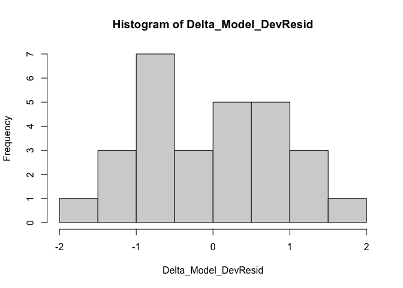

```r
Delta_Model_DevResid <- resid (Delta, type = "deviance")
hist(Delta_Model_DevResid)
```

Check variance of residuals across the range of fitted values (most points should fall within the grey line)

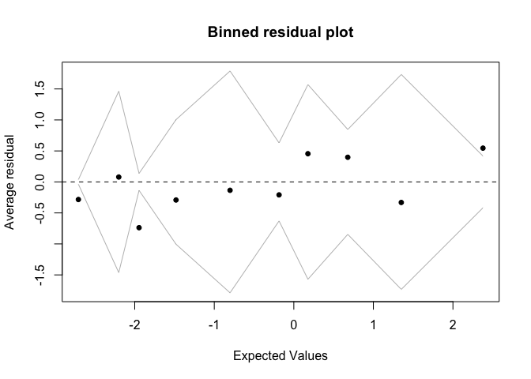

```r
Delta_Model_Predict <- predict(Delta)
binnedplot(Delta_Model_Predict, Delta_Model_DevResid)
```

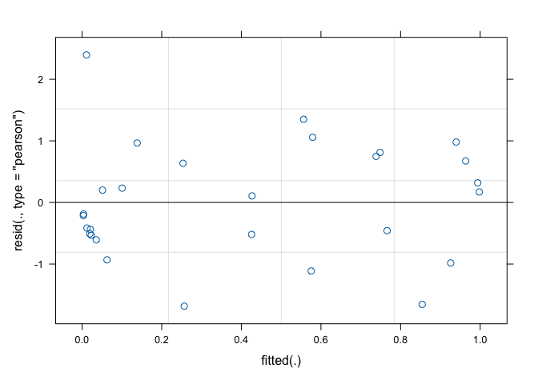

```r
plot(Delta, which = 4)
```

Model fit looks good

### Pairwise comparison of genotype impact

Overall impact of genotype

```r
emmeans(Delta, pairwise ~ Genotype)
```

```
## NOTE: Results may be misleading due to involvement in interactions

## $emmeans
##  Genotype emmean    SE  df asymp.LCL asymp.UCL
##  vgscKO    0.221 0.192 Inf    -0.156     0.598
##  WT        1.140 0.234 Inf     0.681     1.599
##
## Results are given on the probit (not the response) scale.
## Confidence level used: 0.95
##
## $contrasts
##  contrast    estimate    SE  df z.ratio p.value
##  vgscKO - WT   -0.919 0.238 Inf  -3.859  0.0001
##
## Note: contrasts are still on the probit scale. Consider using
##       regrid() if you want contrasts of back-transformed estimates.
```

Impact of genotype at different insecticide levels

```r
emmeans(Delta, pairwise ~ Genotype | Dose,
        at = list(Dose = c(0.05, 0.1, 0.5, 1, 5)))
```

```
## $emmeans
## Dose = 0.05:
##  Genotype emmean    SE  df asymp.LCL asymp.UCL
##  vgscKO   -2.625 0.413 Inf   -3.4346    -1.815
##  WT       -1.967 0.318 Inf   -2.5901    -1.345
##
## Dose = 0.10:
##  Genotype emmean    SE  df asymp.LCL asymp.UCL
##  vgscKO   -1.980 0.323 Inf   -2.6139    -1.347
##  WT       -1.264 0.238 Inf   -1.7312    -0.797
##
## Dose = 0.50:
##  Genotype emmean    SE  df asymp.LCL asymp.UCL
##  vgscKO   -0.484 0.179 Inf   -0.8342    -0.134
##  WT        0.370 0.175 Inf    0.0277     0.712
##
## Dose = 1.00:
##  Genotype emmean    SE  df asymp.LCL asymp.UCL
##  vgscKO    0.160 0.189 Inf   -0.2095     0.530
##  WT        1.073 0.228 Inf    0.6272     1.519
##
## Dose = 5.00:
##  Genotype emmean    SE  df asymp.LCL asymp.UCL
##  vgscKO    1.656 0.354 Inf    0.9624     2.350
##  WT        2.707 0.421 Inf    1.8817     3.532
##
## Results are given on the probit (not the response) scale.
## Confidence level used: 0.95
##
## $contrasts
## Dose = 0.05:
##  contrast    estimate    SE  df z.ratio p.value
##  vgscKO - WT   -0.657 0.454 Inf  -1.448  0.1477
##
## Dose = 0.10:
##  contrast    estimate    SE  df z.ratio p.value
##  vgscKO - WT   -0.717 0.346 Inf  -2.068  0.0386
##
## Dose = 0.50:
##  contrast    estimate    SE  df z.ratio p.value
##  vgscKO - WT   -0.854 0.195 Inf  -4.375 <0.0001
##
## Dose = 1.00:
##  contrast    estimate    SE  df z.ratio p.value
##  vgscKO - WT   -0.913 0.232 Inf  -3.943 <0.0001
##
## Dose = 5.00:
##  contrast    estimate    SE  df z.ratio p.value
##  vgscKO - WT   -1.051 0.456 Inf  -2.306  0.0211
##
## Note: contrasts are still on the probit scale. Consider using
##       regrid() if you want contrasts of back-transformed estimates.
```

**Interpretation** The vgscKO knockout reduces mortality from low dose deltamethrin exposure significantly overall, and at all doses except 0.05 ug/ml.

### Produce prediction grid for plotting

```r
df_Delta$BottleID <- paste0(format(df_Delta$Dose, trim = TRUE), df_Delta$Bottle)
head(df_Delta)
```

```
##   Dose Bottle Genotype Dead Total Alive BottleID
## 1 0.05      A   vgscKO    1    12    11    0.05A
## 2 0.05      B   vgscKO    0    14    14    0.05B
## 3 0.05      C   vgscKO    0    10    10    0.05C
## 4 0.10      A   vgscKO    0    10    10    0.10A
## 5 0.10      B   vgscKO    0    12    12    0.10B
## 6 0.10      C   vgscKO    0    14    14    0.10C
```

```r
pred_grid <- expand_grid(
    Dose = sort(unique(df_Delta$Dose)),
    Genotype = unique(df_Delta$Genotype)
) |>
    mutate(logdose = log10(Dose))


head(pred_grid)
```

```
## # A tibble: 6 × 3
##    Dose Genotype logdose
##   <dbl> <chr>      <dbl>
## 1  0.05 vgscKO    -1.30
## 2  0.05 WT        -1.30
## 3  0.1  vgscKO    -1
## 4  0.1  WT        -1
## 5  0.5  vgscKO    -0.301
## 6  0.5  WT        -0.301
```

```r
pred_link <- predict(
  Delta, newdata = pred_grid, type = "link",
  se.fit = TRUE, re.form = NA
)
inv_link <- pnorm

pred_df <- pred_grid |>
    mutate(
        fit_link = pred_link$fit,
        se_link = pred_link$se.fit,
        fit = inv_link(fit_link),
        lwr = inv_link(fit_link - 1.96 * se_link),
        upr = inv_link(fit_link + 1.96 * se_link)
        )

# Aggregate observed proportions
obs_df <- df_Delta |>
    group_by(Dose, Genotype) |>
    summarise(Dead = sum(Dead),Total = sum(Total), prop = Dead/Total, .groups = "drop")
```

Plot

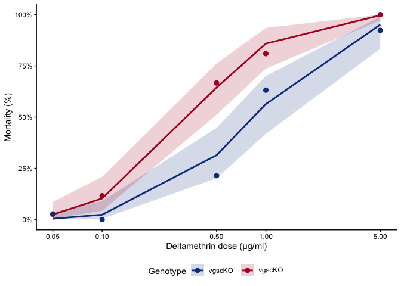

```r
genotype_cols2 <- c(
  "vgscKO" = "#0B3C8C",
  "WT" = "#B11226"
)

genotype_names <- c(
  "vgscKO" = expression(vgscKO^"+"),
  "WT" = expression(vgscKO^"-")
)

ggplot() +
    geom_ribbon(data = pred_df, aes(Dose, ymin = lwr, ymax = upr, fill = Genotype), alpha = 0.18) +
    geom_line(data = pred_df, aes(Dose, y = fit, colour = Genotype), linewidth = 1) +
    geom_point(data = obs_df, aes(Dose, y = prop, colour = Genotype), size = 2.5) +
    scale_color_manual(values = genotype_cols2, labels = genotype_names) +
    scale_fill_manual(values = genotype_cols2, labels = genotype_names) +
    scale_x_log10(breaks = sort(unique(df_Delta$Dose))) +
    scale_y_continuous(labels = percent_format(accuracy = 1), limits = c(0,1)) +
    labs(x = "Deltamethrin dose (µg/ml)", y = "Mortality (%)") +
    theme_classic() +
    theme(legend.position = "bottom")
```

## DDT

Load data

```r
df_DDT <- read.csv("DDTDeadAlive.csv")
head(df_DDT)
```

```
##   Dose Bottle Genotype Dead Total Alive
## 1  0.5      A   vgscKO    0     9     9
## 2  0.5      B   vgscKO    0     9     9
## 3  0.5      C   vgscKO    0     3     3
## 4  1.0      A   vgscKO    0     9     9
## 5  1.0      B   vgscKO    1    10     9
## 6  1.0      C   vgscKO    2     9     7
```

GLM with probit link

```r
DDT <- glmer(cbind(Dead,Alive) ~ log10(Dose) * Genotype + (1 | Dose:Bottle),
              data = df_DDT,
              family = binomial(link = "probit"))

summary(DDT)
```

```
## Generalized linear mixed model fit by maximum likelihood (Laplace
##   Approximation) [glmerMod]
##  Family: binomial  ( probit )
## Formula: cbind(Dead, Alive) ~ log10(Dose) * Genotype + (1 | Dose:Bottle)
##    Data: df_DDT
##
##       AIC       BIC    logLik -2*log(L)  df.resid
##     142.2     150.7     -66.1     132.2        35
##
## Scaled residuals:
##      Min       1Q   Median       3Q      Max
## -1.60070 -0.59338 -0.04063  0.48871  2.82817
##
## Random effects:
##  Groups      Name        Variance Std.Dev.
##  Dose:Bottle (Intercept) 0.09767  0.3125
## Number of obs: 40, groups:  Dose:Bottle, 20
##
## Fixed effects:
##                        Estimate Std. Error z value Pr(>|z|)
## (Intercept)             -1.7930     0.2827  -6.343 2.26e-10 ***
## log10(Dose)              1.0133     0.2047   4.951 7.38e-07 ***
## GenotypeWT               0.1973     0.3113   0.634    0.526
## log10(Dose):GenotypeWT   0.3475     0.2275   1.527    0.127
## ---
## Signif. codes:  0 '***' 0.001 '**' 0.01 '*' 0.05 '.' 0.1 ' ' 1
##
## Correlation of Fixed Effects:
##             (Intr) lg10(D) GntyWT
## log10(Dose) -0.877
## GenotypeWT  -0.746  0.658
## lg10(D):GWT  0.651 -0.712  -0.881
```

Check for overdispersion

```r
rp <- residuals(DDT, type = "pearson")
DDT_over <- sum(rp^2)/df.residual(DDT)
DDT_over
```

```
## [1] 0.9242944
```

Check residuals (should be <2 for good fit)

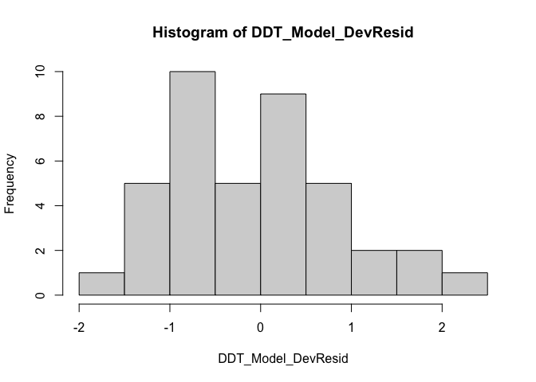

```r
DDT_Model_DevResid <- resid (DDT, type = "deviance")
hist(DDT_Model_DevResid)
```

Check variance of residuals across the range of fitted values (most points should fall within the grey line)

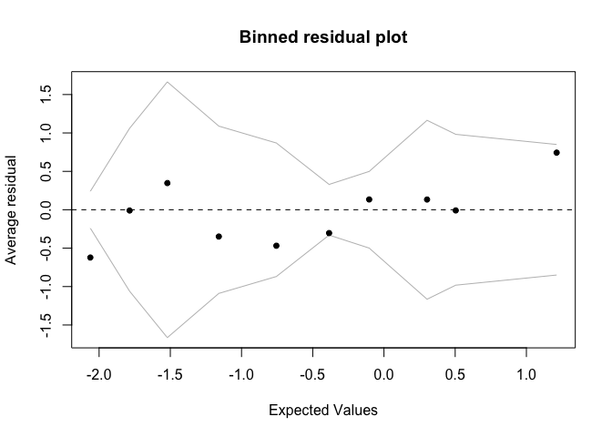

```r
DDT_Model_Predict <- predict(DDT)
binnedplot(DDT_Model_Predict, (DDT_Model_DevResid))
```

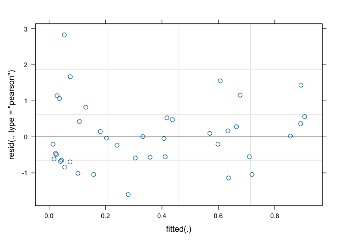

```r
plot(DDT, which = 4)
```

Model fit looks good

### Pairwise comparison of genotype impact

Overall impact of genotype

```r
emmeans(DDT, pairwise ~ Genotype)
```

```
## NOTE: Results may be misleading due to involvement in interactions

## $emmeans
##  Genotype emmean    SE  df asymp.LCL asymp.UCL
##  vgscKO   -0.319 0.145 Inf    -0.603   -0.0357
##  WT        0.384 0.134 Inf     0.121    0.6458
##
## Results are given on the probit (not the response) scale.
## Confidence level used: 0.95
##
## $contrasts
##  contrast    estimate    SE  df z.ratio p.value
##  vgscKO - WT   -0.703 0.158 Inf  -4.455 <0.0001
##
## Note: contrasts are still on the probit scale. Consider using
##       regrid() if you want contrasts of back-transformed estimates.
```

Impact of genotype at different insecticide levels

```r
emmeans(DDT, pairwise ~ Genotype | Dose,
        at = list(Dose = c(0.5, 1, 5, 10, 25, 50, 100)))
```

```
## $emmeans
## Dose =   0.5:
##  Genotype  emmean    SE  df asymp.LCL asymp.UCL
##  vgscKO   -2.0981 0.338 Inf   -2.7606  -1.43556
##  WT       -2.0054 0.256 Inf   -2.5074  -1.50331
##
## Dose =   1.0:
##  Genotype  emmean    SE  df asymp.LCL asymp.UCL
##  vgscKO   -1.7930 0.283 Inf   -2.3471  -1.23897
##  WT       -1.5957 0.213 Inf   -2.0136  -1.17780
##
## Dose =   5.0:
##  Genotype  emmean    SE  df asymp.LCL asymp.UCL
##  vgscKO   -1.0848 0.172 Inf   -1.4211  -0.74845
##  WT       -0.6445 0.133 Inf   -0.9059  -0.38315
##
## Dose =  10.0:
##  Genotype  emmean    SE  df asymp.LCL asymp.UCL
##  vgscKO   -0.7797 0.143 Inf   -1.0591  -0.50036
##  WT       -0.2349 0.119 Inf   -0.4676  -0.00221
##
## Dose =  25.0:
##  Genotype  emmean    SE  df asymp.LCL asymp.UCL
##  vgscKO   -0.3765 0.141 Inf   -0.6531  -0.09999
##  WT        0.3066 0.130 Inf    0.0525   0.56079
##
## Dose =  50.0:
##  Genotype  emmean    SE  df asymp.LCL asymp.UCL
##  vgscKO   -0.0715 0.169 Inf   -0.4018   0.25885
##  WT        0.7163 0.157 Inf    0.4087   1.02385
##
## Dose = 100.0:
##  Genotype  emmean    SE  df asymp.LCL asymp.UCL
##  vgscKO    0.2335 0.211 Inf   -0.1799   0.64699
##  WT        1.1259 0.193 Inf    0.7469   1.50492
##
## Results are given on the probit (not the response) scale.
## Confidence level used: 0.95
##
## $contrasts
```

[output cut: 15 more lines]

```
##
## Dose =  25.0:
##  contrast    estimate    SE  df z.ratio p.value
##  vgscKO - WT  -0.6831 0.154 Inf  -4.448 <0.0001
##
## Dose =  50.0:
##  contrast    estimate    SE  df z.ratio p.value
##  vgscKO - WT  -0.7878 0.185 Inf  -4.255 <0.0001
##
## Dose = 100.0:
##  contrast    estimate    SE  df z.ratio p.value
##  vgscKO - WT  -0.8924 0.233 Inf  -3.828  0.0001
##
## Note: contrasts are still on the probit scale. Consider using
##       regrid() if you want contrasts of back-transformed estimates.
```

**Interpretation** The vgscKO knockout reduces mortality from low dose DDT exposure significantly overall, and at all doses except 0.5 ug/ml and 1 ug/ml.

### Produce prediction grid for plotting

```r
df_DDT$BottleID <- paste0(format(df_DDT$Dose, trim = TRUE), df_DDT$Bottle)
head(df_DDT)
```

```
##   Dose Bottle Genotype Dead Total Alive BottleID
## 1  0.5      A   vgscKO    0     9     9     0.5A
## 2  0.5      B   vgscKO    0     9     9     0.5B
## 3  0.5      C   vgscKO    0     3     3     0.5C
## 4  1.0      A   vgscKO    0     9     9     1.0A
## 5  1.0      B   vgscKO    1    10     9     1.0B
## 6  1.0      C   vgscKO    2     9     7     1.0C
```

```r
pred_grid <- expand_grid(
    Dose = sort(unique(df_DDT$Dose)),
    Genotype = unique(df_DDT$Genotype)
) |>
    mutate(logdose = log10(Dose))


head(pred_grid)
```

```
## # A tibble: 6 × 3
##    Dose Genotype logdose
##   <dbl> <chr>      <dbl>
## 1   0.5 vgscKO    -0.301
## 2   0.5 WT        -0.301
## 3   1   vgscKO     0
## 4   1   WT         0
## 5   5   vgscKO     0.699
## 6   5   WT         0.699
```

```r
pred_link <- predict(
  DDT, newdata = pred_grid, type = "link",
  se.fit = TRUE, re.form = NA
)
inv_link <- pnorm

pred_df <- pred_grid |>
    mutate(
        fit_link = pred_link$fit,
        se_link = pred_link$se.fit,
        fit = inv_link(fit_link),
        lwr = inv_link(fit_link - 1.96 * se_link),
        upr = inv_link(fit_link + 1.96 * se_link)
        )

# Aggregate observed proportions
obs_df <- df_DDT |>
    group_by(Dose, Genotype) |>
    summarise(Dead = sum(Dead),Total = sum(Total), prop = Dead/Total, .groups = "drop")
```

Plot

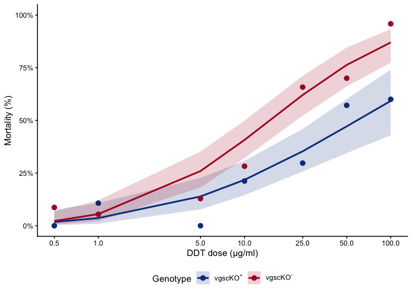

```r
genotype_cols2 <- c(
  "vgscKO" = "#0B3C8C",
  "WT" = "#B11226"
)

genotype_names <- c(
  "vgscKO" = expression(vgscKO^"+"),
  "WT" = expression(vgscKO^"-")
)

ggplot() +
    geom_ribbon(data = pred_df, aes(Dose, ymin = lwr, ymax = upr, fill = Genotype), alpha = 0.18) +
    geom_line(data = pred_df, aes(Dose, y = fit, colour = Genotype), linewidth = 1) +
    geom_point(data = obs_df, aes(Dose, y = prop, colour = Genotype), size = 2.5) +
    scale_color_manual(values = genotype_cols2, labels = genotype_names) +
    scale_fill_manual(values = genotype_cols2, labels = genotype_names) +
    scale_x_log10(breaks = sort(unique(df_DDT$Dose))) +
    scale_y_continuous(labels = percent_format(accuracy = 1), limits = c(0,1)) +
    labs(x = "DDT dose (µg/ml)", y = "Mortality (%)") +
    theme_classic() +
    theme(legend.position = "bottom")
```

## LC tables for both insecticides

Load combined data

```r
df <- read.csv("InsecticideDeadAlive.csv")
head(df)
```

```
##    Insecticide Dose Bottle Genotype Dead Total Alive
## 1 Deltamethrin 0.05      A   vgscKO    1    12    11
## 2 Deltamethrin 0.05      B   vgscKO    0    14    14
## 3 Deltamethrin 0.05      C   vgscKO    0    10    10
## 4 Deltamethrin 0.10      A   vgscKO    0    10    10
## 5 Deltamethrin 0.10      B   vgscKO    0    12    12
## 6 Deltamethrin 0.10      C   vgscKO    0    14    14
```

```r
df_clean <- subset(df,
                   Dose > 0 &
                   !is.na(Dose) &
                   !is.na(Dead) &
                   !is.na(Total) &
                   Total > 0
)
nrow(df)
```

```
## [1] 72
```

```r
nrow(df_clean)
```

```
## [1] 68
```

```r
KO_delta <- LC_probit((Dead/Total) ~ log10(Dose),
          p = c(50,90,95,99),
          weights = Total,
          data = df_clean,
          subset = df_clean$Genotype == "vgscKO" & df_clean$Insecticide == "Deltamethrin"
)

WT_delta <- LC_probit((Dead/Total) ~ log10(Dose),
          p = c(50,90,95,99),
          weights = Total,
          data = df_clean,
          subset = df_clean$Genotype == "WT" & df_clean$Insecticide == "Deltamethrin"
)

KO_DDT<- LC_probit((Dead/Total) ~ log10(Dose),
          p = c(50,90,95,99),
          weights = Total,
          data = df_clean,
          subset = df_clean$Genotype == "vgscKO" & df_clean$Insecticide == "DDT"
)

WT_DDT<- LC_probit((Dead/Total) ~ log10(Dose),
          p = c(50,90,95,99),
          weights = Total,
          data = df_clean,
          subset = df_clean$Genotype == "WT" & df_clean$Insecticide == "DDT"
)
```

```r
KO_delta2 <- KO_delta %>%
  mutate(Genotype = "vgscKO",
         Insecticide = "Deltamethrin")

WT_delta2 <- WT_delta %>%
  mutate(Genotype = "WT",
         Insecticide = "Deltamethrin")

KO_DDT2 <- KO_DDT %>%
  mutate(Genotype = "vgscKO",
         Insecticide = "DDT")

WT_DDT2 <- WT_DDT %>%
  mutate(Genotype = "WT",
         Insecticide = "DDT")

LC_all <- bind_rows(KO_delta2, WT_delta2, KO_DDT2, WT_DDT2)

LC_trimmed <- LC_all %>%
  dplyr::select(Genotype, Insecticide, p, dose, LCL, UCL, se)

LC_trimmed
```

```
## # A tibble: 16 × 7
##    Genotype Insecticide      p      dose      LCL        UCL    se
##    <chr>    <chr>        <dbl>     <dbl>    <dbl>      <dbl> <dbl>
##  1 vgscKO   Deltamethrin    50     0.770    0.455      1.48   1.16
##  2 vgscKO   Deltamethrin    90     3.43     1.70      19.0    1.32
##  3 vgscKO   Deltamethrin    95     5.24     2.33      41.7    1.39
##  4 vgscKO   Deltamethrin    99    11.6      4.11     185.     1.53
##  5 WT       Deltamethrin    50     0.351    0.272      0.453  1.14
##  6 WT       Deltamethrin    90     1.34     0.953      2.17   1.22
##  7 WT       Deltamethrin    95     1.95     1.32       3.48   1.27
##  8 WT       Deltamethrin    99     3.97     2.40       8.56   1.36
##  9 vgscKO   DDT             50    58.3     34.1      142.     1.39
## 10 vgscKO   DDT             90  1103.     342.     12789.     2.23
## 11 vgscKO   DDT             95  2538.     636.     47308.     2.60
## 12 vgscKO   DDT             99 12121.    2025.    555183.     3.46
## 13 WT       DDT             50    15.5      8.59      28.3    1.17
## 14 WT       DDT             90   140.      64.3      638.     1.32
## 15 WT       DDT             95   261.     104.      1679.     1.40
## 16 WT       DDT             99   839.     253.     10586.     1.57
```